# Monte Carlo Approximation

**Hady Hosam**

Many important integrals have no closed-form antiderivative. A central example is the Gaussian integral $$ \int_{-\infty}^{\infty} e^{-x^2}\,dx. $$ Its value can be obtained by a geometric argument in two dimensions. The same integral also provides a natural setting for **Monte Carlo estimation**, a numerical approach to approximating expectations.

**Goals of this notebook**

1. Evaluate the Gaussian integral using a classical geometric argument.
2. Interpret the integral as an expectation.
3. Approximate the integral numerically via Monte Carlo sampling on a finite interval.
4. Discuss convergence and variance (why error typically scales like $1/\sqrt{N}$).

Monte Carlo methods are widely used when closed forms are unavailable. In quantitative finance, expectations under stochastic models are often computed by simulation; while those models are more complex, the mathematical principle is the same.

## 1. The Gaussian Integral

Define $$ I \;=\; \int_{-\infty}^{\infty} e^{-x^2}\,dx. $$ The function $e^{-x^2}$ has no elementary antiderivative. To evaluate $I$, we square the integral and interpret the result as a double integral: $$ I^2 \;=\; \left(\int_{-\infty}^{\infty} e^{-x^2}\,dx\right) \left(\int_{-\infty}^{\infty} e^{-y^2}\,dy\right) \;=\; \int_{-\infty}^{\infty}\!\!\int_{-\infty}^{\infty} e^{-(x^2+y^2)}\,dx\,dy. $$ Because the integrand depends only on $r^2=x^2+y^2$, we switch to polar coordinates: $$ x=r\cos\theta,\quad y=r\sin\theta,\quad dx\,dy = r\,dr\,d\theta. $$ Then $$ I^2 \;=\; \int_{0}^{2\pi}\!\int_{0}^{\infty} e^{-r^2}\,r\,dr\,d\theta. $$ Let $u=r^2$ so $du=2r\,dr$: $$ \int_{0}^{\infty} e^{-r^2}\,r\,dr \;=\; \tfrac{1}{2}\int_{0}^{\infty} e^{-u}\,du \;=\; \tfrac{1}{2}. $$

$$ I^2 \;=\; 2\pi \cdot \tfrac{1}{2} \;=\; \pi, $$

$$ \boxed{\,I=\sqrt{\pi}\,}. $$

### 1.1 Symbolic verification (SymPy)

```python
import sympy as sp
x = sp.symbols('x', real=True)
sp.integrate(sp.exp(-x**2), (x, -sp.oo, sp.oo))
```

$\displaystyle \sqrt{\pi}$

## 2. The Integral as an Expectation

The Gaussian integral appears naturally in probability theory. If we normalize the function $e^{-x^2}$, we obtain the density of a normal distribution. This lets us reinterpret the integral $$ \int_{-\infty}^{\infty} e^{-x^2}\,dx $$ as an **expected value**.

Define $$ f(x) = e^{-x^2}, $$ and consider the probability density $$ p(x) = \frac{1}{\sqrt{\pi}} e^{-x^2}. $$ Then $p(x)$ is a valid probability density on $\mathbb{R}$, since $$ \int_{-\infty}^{\infty} p(x)\,dx = 1. $$ With this normalization, we can write $$ \int_{-\infty}^{\infty} e^{-x^2}\,dx = \sqrt{\pi}\,\mathbb{E}_{p}[\,1\,]. $$

More usefully, if we want to approximate the integral $$ \int_{-\infty}^{\infty} e^{-x^2}\,dx, $$ we can instead approximate the *expectation* $$ \mathbb{E}_{p}[\,g(X)\,] $$ for a suitable function $g$, where $X$ is drawn from the density $p(x)$.

### 2.1 Restricting to a Finite Interval

In practice, direct sampling from the density $p(x)$ is not always convenient. Instead, we approximate the integral over a large but finite symmetric interval: $$ \int_{-L}^{L} e^{-x^2}\,dx \approx I = \sqrt{\pi}. $$

For sufficiently large $L$, the function $e^{-x^2}$ is very close to zero outside this interval.
A typical choice (and the one I use below) is: $$ L = 3 $$ which captures almost all of the mass of a standard Gaussian.

### 2.2 Monte Carlo Approximation

Suppose we draw $N$ points $x_1, \dots, x_N$ uniformly from the interval $[-L, L]$. We approximate the integral by: $$ \hat{I}_N = \frac{2L}{N} \sum_{k=1}^{N} e^{-x_k^2}. $$ The factor $2L$ accounts for the width of the interval, since uniform sampling averages the function value and then scales by the interval length.

As $N$ increases, the estimate $\hat{I}_N$ converges (in probability) to $I=\sqrt{\pi}$.

### 2.3 Code: Monte Carlo Approximation on $[-3,3]$

```python
import numpy as np
print("Exact Value = ",np.sqrt(np.pi))
def monte_carlo_gaussian(N, L=3):
    x = np.random.uniform(-L, L, size=N)
    estimates = (2*L) * np.mean(np.exp(-x**2))
    return estimates

# Estimates using increasing sample sizes
for N in [100, 1_000, 10_000, 100_000]:
    print(f"N={N}: Estimate = {monte_carlo_gaussian(N)}")
```

```
Exact Value =  1.7724538509055159
N=100: Estimate = 1.669575805020949
N=1000: Estimate = 1.8349216331807292
N=10000: Estimate = 1.7539556407109096
N=100000: Estimate = 1.7762417765636824
```

## 3. Why Monte Carlo Converges: The $1/\sqrt{N}$ Error Rate

Monte Carlo integration replaces an integral with the average of randomly sampled function values.  
This means that the accuracy of the approximation depends on how the sample mean behaves.

Let $X$ be a random variable drawn uniformly from $[-L, L]$, and define $$ Y = e^{-X^2}. $$ Our Monte Carlo estimator for the integral is: $$ \hat{I}_N = \frac{2L}{N} \sum_{k=1}^{N} Y_k, $$ where $Y_1, \dots, Y_N$ are independent copies of $Y$.

### 3.1 Expected Value and Bias

The estimator $\hat{I}_N$ is **unbiased**: $$ \mathbb{E}[\hat{I}_N] = \int_{-L}^{L} e^{-x^2}\,dx. $$

This means that, *on average*, the estimator converges to the correct value.

### 3.2 Variance and Fluctuation Size

The variability of the estimator comes from the randomness in the sampled values. Since the $Y_k$ are independent, $$ \text{Var}(\hat{I}_N) = \frac{(2L)^2}{N^2}\,\text{Var}\!\left(\sum_{k=1}^{N}Y_k\right) = \frac{(2L)^2}{N}\,\text{Var}(Y). $$

Taking square roots gives the standard deviation: $$ \text{Std}(\hat{I}_N) \propto \frac{1}{\sqrt{N}}. $$

This is the **fundamental scaling law** of Monte Carlo methods:

- Doubling the accuracy requires **four times** as many samples.
- Gaining one decimal digit of accuracy requires **100× more samples**.

This is both the strength and the limitation of Monte Carlo:

- Works in any dimension, even when grids fail.
- Converges slowly compared to deterministic numerical methods.

### 3.3 Experiment: Observing the $1/\sqrt{N}$ Rate

Below, I estimate the integral many times and record the error:

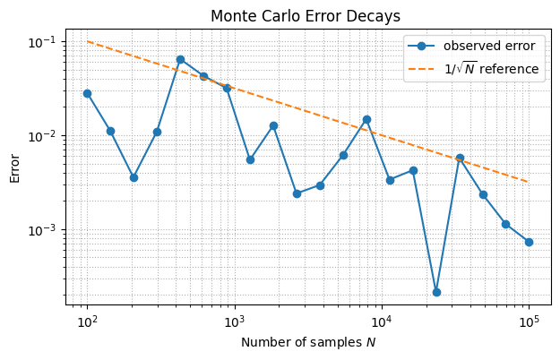

```python
import numpy as np

def mc_estimate(N, L=3):
    x = np.random.uniform(-L, L, size=N)
    return (2*L) * np.mean(np.exp(-x**2))

true_value = np.sqrt(np.pi)
sample_sizes = np.logspace(2, 5, 20, dtype=int)  # from 1e2 to 1e5
errors = []

for N in sample_sizes:
    estimates = [mc_estimate(N) for _ in range(10)]
    avg_estimate = np.mean(estimates)
    errors.append(abs(avg_estimate - true_value))

import matplotlib.pyplot as plt

plt.figure(figsize=(7,4))
plt.loglog(sample_sizes, errors, marker='o', label=r"observed error")
plt.loglog(sample_sizes, 1/np.sqrt(sample_sizes), linestyle='--', label=r"$1/\sqrt{N}$ reference")
plt.xlabel(r"Number of samples $N$")
plt.ylabel(r"Error")
plt.title(r"Monte Carlo Error Decays ")
plt.legend()
plt.grid(True, which="both", ls=":")
plt.show()
```

The error curve fluctuates randomly, but overall it tracks the dashed $1/\sqrt{N}$ line. This confirms the theoretical prediction from the variance calculation. Even with large $N$, the error decreases gradually, illustrating why Monte Carlo is powerful but slow.

## 4. Sampling from Non-Uniform Distributions

Up to this point, all Monte Carlo estimates used the uniform distribution. Many important probability distributions are not uniform. A central example is the standard normal distribution: $$ X \sim \mathcal{N}(0,1), \qquad f(x) = \frac{1}{\sqrt{2\pi}} e^{-x^{2}/2}. $$

Unlike the uniform case, there is no simple algebraic inverse that turns a uniform random variable into a normal one. Instead, we use a general construction called acceptance–rejection sampling.

### 4.1 The Acceptance–Rejection Method

The goal is to generate samples from a density $f(x)$. We Choose another density $g(x)$ that is easy to sample from and satisfies $$ f(x) \le C\, g(x) \quad \text{for some constant } C \ge 1. $$

The procedure is:

1. Sample $Y \sim g$.
2. Sample $U \sim \text{Uniform}(0,1)$.
3. Accept $Y$ if $$ U \le \frac{f(Y)}{C\,g(Y)}. $$
4. Otherwise, reject $Y$ and repeat.

All accepted values have density $f(x)$.

Any distribution can be sampled using only uniform randomness and a comparison test, provided a suitable $g$ and $C$ are available.

### 4.2 Example: Sampling from the Standard Normal

Target density: $$ f(x) = \frac{1}{\sqrt{2\pi}} e^{-x^{2}/2}. $$

Proposal density (uniform on $[-5,5]$): $$ g(x) = \frac{1}{10}, \qquad -5 \le x \le 5. $$

### 4.3 Why This Matters

- Monte Carlo methods work with probability distributions even when no closed-form inverse exists.
- A distribution becomes something we can generate from, not only write down symbolically.
- This viewpoint underlies more advanced stochastic modeling:
  - Markov Chain Monte Carlo (MCMC)
  - Brownian motion simulation
  - Stochastic differential equations (SDEs)

For instance, the **Black Scholes** equation: $$ dS_t = \mu S_t\,dt + \sigma S_t\,dW_t, $$ where randomness enters via samples from $\mathcal{N}(0,1)$.

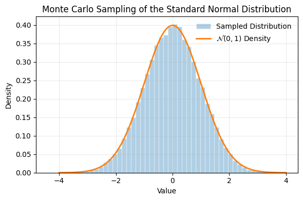

```python
import numpy as np
import matplotlib.pyplot as plt
from scipy.stats import norm

# Monte Carlo sampling
N = 50_000
samples = np.random.randn(N)


x = np.linspace(-4, 4, 400)
true_density = norm.pdf(x)

plt.figure(figsize=(6,4))

# Histogram (normalized)
plt.hist(samples, bins=50, density=True, alpha=0.35, edgecolor='white', label=r"Sampled Distribution")

# True Normal Density
plt.plot(x, true_density, linewidth=2, label=r"$\mathcal{N}(0,1)$ Density")

plt.title(r"Monte Carlo Sampling of the Standard Normal Distribution")
plt.xlabel(r"Value")
plt.ylabel(r"Density")
plt.legend(frameon=False)
plt.grid(alpha=0.25)

plt.tight_layout()
plt.show()
```

## 5. Estimating $\pi$ Using Monte Carlo Sampling

Monte Carlo methods estimate quantities by drawing random samples and averaging their contributions. Here, the goal is to estimate $\pi$ using uniform points in the plane.

Consider the square $$ [-1,1]\times[-1,1], $$ which has area $4$, and the unit disk $$ x^2 + y^2 \le 1, $$ which has area $\pi$. If points are drawn uniformly from the square, the probability that a point lands inside the disk equals the ratio of areas: $$ \frac{\text{points inside}}{\text{total points}} \approx \frac{\pi}{4}. $$ Therefore, $$ \pi \approx 4 \cdot \frac{\text{points inside}}{\text{total points}}. $$

As the number of samples $N$ increases, the Law of Large Numbers implies that this estimate converges to $\pi$. The typical error decreases at the Monte Carlo rate $$ \text{Error} \sim \frac{1}{\sqrt{N}}, $$

```
Monte Carlo estimate of π with N = 3000: 3.201333
```

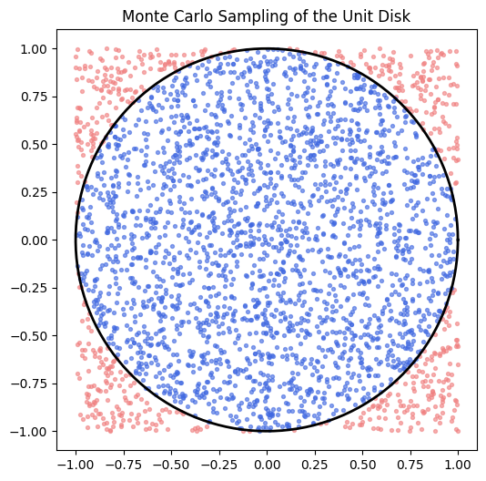

```python
N = 3000
x = np.random.uniform(-1, 1, N)
y = np.random.uniform(-1, 1, N)

inside = x**2 + y**2 <= 1
pi_estimate = 4 * np.mean(inside)
print(f"Monte Carlo estimate of π with N = {N}: {pi_estimate:.6f}")

plt.figure(figsize=(6,6))
plt.scatter(x[~inside], y[~inside], s=8, color="lightcoral", alpha=0.6)
plt.scatter(x[inside], y[inside], s=8, color="royalblue", alpha=0.6)

theta = np.linspace(0, 2*np.pi, 300)
plt.plot(np.cos(theta), np.sin(theta), color="black", linewidth=2)

plt.gca().set_aspect("equal")
plt.title("Monte Carlo Sampling of the Unit Disk")
plt.show()
```

# 6. Summary

Monte Carlo methods approximate expectations by averaging randomly sampled outcomes. In each example, a quantity of interest was written in the form

$ \mathbb{E}[f(X)] $

and then estimated using $N$ independent samples. The empirical mean approaches the true value as

$ \text{error} \sim \frac{1}{\sqrt{N}}, $ which is slow but dimension-independent. This is one of the main reasons Monte Carlo is widely used when classical numerical integration becomes difficult.